# Building R Packages

## What are R Packages?

## R Packages

1. Sets of Functions
2. Set of Functions + Documentation
3. Set of Functions + Documentation + Data
4. Set of Functions + Documentation + Data + Vignettes
5. Set of Functions + Documentation + Data + Vignettes + Versions
6. Set of Functions + Documentation + Data + Vignettes + Versions + Dependencies

## Windows and RTools

If you have a Windows machine, you need to install RTools from https://cran.r-project.org/bin/windows/Rtools/ (choose the frozen one).

[figure not shown]

## Checking Package Names

Try the `available::available` function:

```r
available::available("ggplot")
```

```
## ── ggplot ───────────────────────────────────────────────────────────────────────────────────────────────────────────────────────────────────────
## Name valid: ✔
## Available on CRAN: ✖
## Available on Bioconductor: ✔
## Available on GitHub:  ✖
## Abbreviations: http://www.abbreviations.com/ggplot
## Wikipedia: https://en.wikipedia.org/wiki/ggplot
## Wiktionary: https://en.wiktionary.org/wiki/ggplot
## Sentiment:???
```

## Starting Up

Use RStudio and the `devtools` and `usethis` packages. It’s easier.

```r
install.packages(c("devtools", "usethis"))
```

In RStudio, File -> New Project -> New Directory -> R Package with devtools (scroll down), with a name:

- must start with letter
- no underscores
- periods allowable or use CamelCase
- can have numbers

## Start with Git and Put on GitHub/GitLab

This is so people (including you on the cluster) can:

1. See it
2. Use it
3. Install it

```r
usethis::use_git() # make a Git repo
usethis::use_github() # must have GITHUB_PAT set up
usethis::use_github(protocol = "https") # must have GITHUB_PAT set up
```

## Documentation is a pain

…but it’s worthwhile. Writing out argument definitions makes it easier to identify if argument names make sense.

[figure not shown]

From https://imgflip.com/i/4mvkhl

## Documentation is a pain

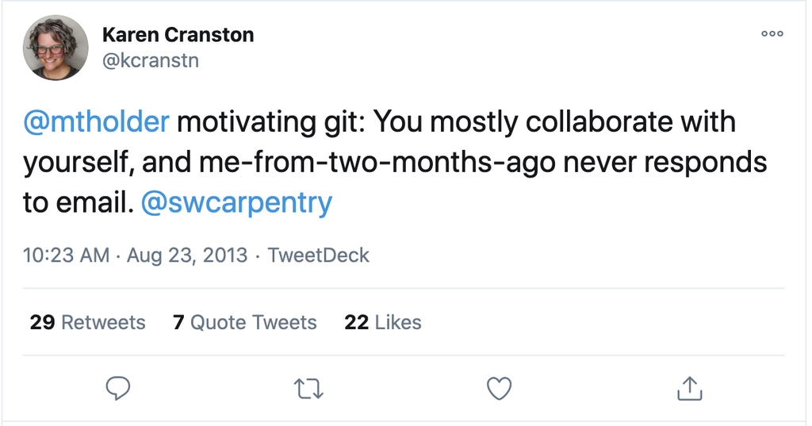

https://twitter.com/kcranstn/status/370914072511791104

## Use Roxygen2

Go to Build -> Configure Build Tools. Click Generate documents with Roxygen. If that is gray, install `roxygen2`:

```r
install.packages("roxygen2")
```

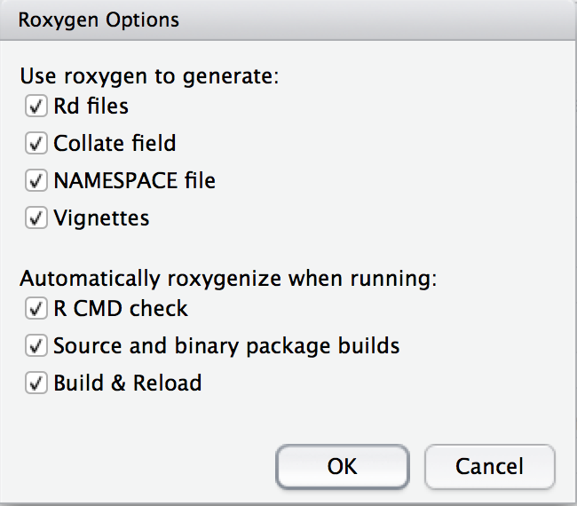

Click “Configure” - click all the boxes.

## DESCRIPTION file

In the RStudio project, go to “Go to file/function” search bar on the menu bar.

- This searches through the files in the package.
  - Also searches for **function names** and can go to that function in the file

Type “DESCRIPTION” and open that file.

[figure not shown]

## DESCRIPTION file

- `Title - What the Package Does (Title Case)`
- `Authors@R: c(person("first", "last"))` - `usethis::use_author()`
  - `comment = c(ORCID = "ORCID-ID")`
- `Description: Use paragraph prose here. Don't start with word package` Use 2-4 spaces when indenting paragraphs within the Description.
- “License:”, `usethis::use_*_license`

## Authors

I add this to the `DESCRIPTION` file:

```
Authors@R: c(person(given = "John",
           family = "Muschelli",
           email = "muschellij2@gmail.com",
           role = c("aut", "cre"),
           comment = c(ORCID = "0000-0001-6469-1750")))
```

Use `Authors@R` even if there is only one author.

## License

`usethis::use_gpl3_license("John Muschelli")`

- https://www.r-project.org/Licenses/

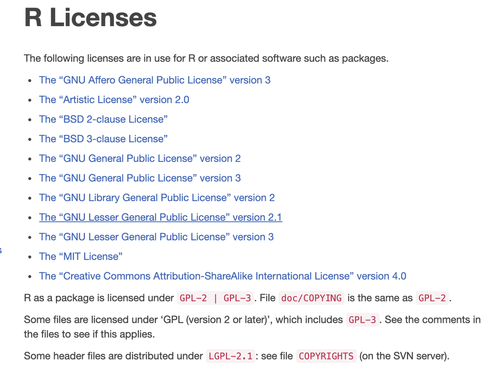

## DESCRIPTION file: additional fields

- You do not use `library` or `require` in functions in a package
- Imports: package1, package2
  - packages with specific functions called in package
  - Anything other than `base` package needs to be imported (`stats`, `methods`)
  - does not expose all functions to user
- Depends: package3, package5 - **do not use other than `R(>=RVERSION)`**
  - packages with **ALL** functions loaded when call your package
- Suggests: package4, package6
  - used in **examples** or **vignettes** (check if installed)

```r
usethis::use_package("tidyr", type = "Imports")
usethis::use_package("dplyr", type = "Suggests")
```

## Description Field (in `DESCRIPTION` file)

- Change the `Description` field so that it’s a sentence and it ends with a period.
- Pu single quotes around weird words (like science-specific).
- Make sure to put links in angle brackets (`<http...>`). Use DOIs if you can.
- If you go too long on a line, indent it with 4 spaces `" "`.

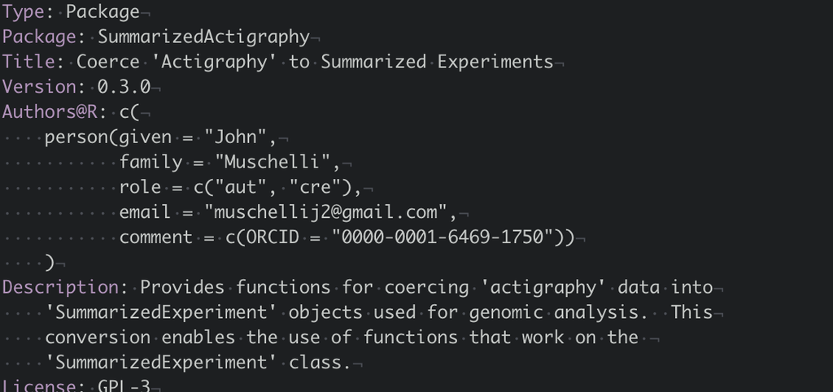

## Roxygen2

Roxygen allows for functions and documentation in the same file. Let’s make a function:

```r
top = function(x, n) {
  xx = x[1:n, 1:n]
  hist(xx)
  print(xx)
}
```

Save this to `top.R` file in `R/` (where R functions are).

## Roxygen2

Highlight the code of a function definition:

```r
top = function(x, n) {
```

Go to Code -> Insert Roxygen Skeleton

## Roxygen Skeleton Output

```r
#' Title
#'
#' @param x
#' @param n
#'
#' @returns
#' @export
#' @examples
```

- `@param` stands for a parameter/argument for that function.
- `@returns` denotes what the function returns. This is required.
- `@export` - when people install your package, can they use this function
  - non-exported functions are usually helpers, really small, or not fully formed yet
- `@examples` - code to show how the function works. Wrap functions in `\dontrun{}` if not wanted to run

## Roxygen Skeleton:

You can add `@title` and `@description` tags:

```r
#' @title
#' @description
#'
#' @param x
```

…

## Roxygen Skeleton:

```r
#' @title Print the top of a matrix
#' @description `top` is a small function to not just present the first rows
#' of a matrix, but also the first number of columns
#'
#' @param x a `matrix`
#' @param n Number of rows and columns to display of the matrix,
#' similar to [utils::head()]
#'
#' @returns The matrix that is subset based on parameters
#' @export
#'
#' @examples
#' mat = matrix(rnorm(100), nrow = 10)
#' top(mat, n = 4)
#' \dontrun{
#'    top(mat, n = 10)
#' }
```

## Organizing Functions: a little style

1. Create a file for each function (preference) or at least group. Name file function name.
2. Optional arguments: Set to `NULL` and use `is.null()` to test
3. Put functions together: use `#' @rdname`.
4. See `#' @inheritParams` for different functions with the same arguments.
5. Add logical `verbose` argument for printing
6. Use `message` (not `cat`) for printing. Someone can use `suppressMessages` to stop the printing. Wrap these with `if (verbose)`
7. Pass `...` to a main function for additional options for the user.
8. Have examples (vignette too) - `usethis::use_vignette()`
9. Learn `do.call(FUNCTION, args = list_of_arguments)`
10. Notify/warn/message whenever you have to.

## Functions are Verbs (action words)

## NAMESPACE

The `NAMESPACE` files tells the R package what to import and export. In Roxygen:

- `@export` - adds this to the NAMESPACE file
  - when package is installed, users can call this function
- `@import` - in roxygen, if you want to import a **package**, you say `@import PACKAGENAME`
  - imports **ALL** functions from that package
  - if package is listed under Depends in DESCRIPTION, then the **whole package** is loaded when you load your package
  - otherwise it simply exposes them for your package to use them, but not the user, users still have to do `library(PACKAGENAME)`

## NAMESPACE

- `@importFrom` - in roxygen, if you want to import a **function**, you say `@import PACKAGENAME func1 func2`
  - only imports these functions. Better way of doing things.
  - if `pkgA` has function `dothing` and `pkgB` has functions `dothing` and `other`, if `@import pkgA dothing`, `@import pkgB other`, then if you call `dothing()`, R knows it’s from `pkgA`
  - you must import anything explicitly other than from the `base` package, includying anything from `stats` (e.g. `quantile`) or `graphics` (e.g. `hist`)

Add `@importFrom graphics hist` to your top.R file

**Typically**: create `imports.R` because you only need to import stuff in **one place**. Keeping in multiple places is hard to track.

## NAMESPACE - alternative

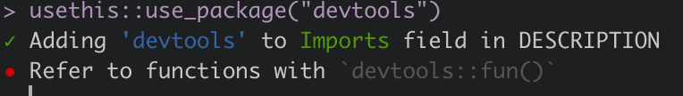

For every function you’re using from a package, use `package::function()`

- Preferred way, especially only using infrequently
- Don’t need an `@import` or `@importFrom` tag
- Annoying with frequent functions (e.g. `dplyr`), so you can use `import`

If using `magrittr::%>%`, run:

```r
usethis::use_pipe()
```

## Build and Reload

- Go to Build -> Build and Reload the package
  - First time you may see some warnings (no NAMESPACE file!)
  - Rerunning should get rid of these
  - look in the folders
- Then try Build -> Check Package

## Documenting Your Package (Overall)

Creates help file for an overview of your package (not many read it in my experience).

```r
usethis::use_package_doc()
```

## Including Data

The `data-raw` directory can be data you want to create (such as simulated data).

This will have scripts with `use_data` at the end to make the data (next slide)

```r
usethis::usethis::use_data_raw()
```

## Including Data

The `data/` directory is where data goes, it **must** be named `.RData` or `rda`. The `use_data` function can do this for you:

```r
usethis::use_data(DATAOBJECT, compress = "xz")
```

The output will be `DATAOBJECT.rda` in the `data` folder. You can use this in your package

## Documenting Data

Note how `DATAOBJECT` is the name of the object/rda. Now we can document the data as follows:

```r
#' @title Some object to document
#'
#' @description A list containing things
#'
#' @format A list with 7 elements, which are:
#' \describe{
#' \item{x}{first thing}
#' \item{y}{second thing}
#' }
"DATAOBJECT"
```

## Different kinds of data

The `inst/` directory will copy any of the contents to the installed directory path. So if `blah.csv` was in `inst/` then it will be in the directory.

Most times, however, people put data in `inst/extdata` to separate folders out.

You can use `find.package` to find the installed directory:

```r
find.package("readr")
```

```
## [1] "/Library/Frameworks/R.framework/Versions/4.4-x86_64/Resources/library/readr"
```

To get files, though, you should use `system.file`:

```r
system.file("extdata", package = "readr")
```

```
## [1] "/Library/Frameworks/R.framework/Versions/4.4-x86_64/Resources/library/readr/extdata"
```

## Different kinds of data

If you pass in multiple characters, it assumes you put it together with `file.path`:

```r
system.file("extdata", "challenge.csv", package = "readr")
```

```
## [1] "/Library/Frameworks/R.framework/Versions/4.4-x86_64/Resources/library/readr/extdata/challenge.csv"
```

The `mustWork` argument is useful for making sure the file exists:

```r
system.file("extdata", "asdfsdf.csv", package = "readr", mustWork = TRUE)
```

```
## Error in system.file("extdata", "asdfsdf.csv", package = "readr", mustWork = TRUE): no file found
```

## Aside: Using the file system

1. `file.path` > `paste` for paths (or `fs` package)
2. Use `file.exists`. Use `any` and `all`
3. `file.remove` if you need to delete things
4. Make temporary (empty, non-existent) files, with extension: `tempfile(fileext = ".csv")`.
5. `dir.create` to create and `unlink` to destroy directories.
6. Using `tempdir()` for stuff that’s intermediate.
7. Temporary sub-directory: `tdir = tempfile(); dir.create(tdir); on.exit({ unlink(tdir) })`
8. `file.copy` and `file.rename`
9. `download.file` or `curl::curl_download`

## Vignettes

- http://r-pkgs.had.co.nz/vignettes.html

A package has data + code + dependencies. A vignette can tie this together to tell you **how** to use the package. Typically it is an analysis.

- **THIS IS EXACTLY WHAT A REPRODUCIBLE PAPER IS!**

```r
usethis::use_vignette("my-vignette")
```

- Can make private packages that are the workflow for your paper

## Unit tests

The `testthat` package is great for unit testing. Put test scripts in `tests/testthat`, always named `test-DESCRIPTOR.R`. To set up `testthat`:

```r
usethis::use_testthat()
```

And a specific test:

```r
usethis::use_test("name of test")
```

### **General Rule: Any package issue turns into a test.**

## Unit tests

The `testthat` package is great for unit testing. Put test scripts in `tests/testthat`, always named `test-DESCRIPTOR.R`. To set up `testthat`:

```r
testthat::context("OVERALL DESCRIPTION OF TESTS IN THIS FILE")
testthat::test_that("Description of this test", { MYCODE })
testthat::expect_equal(OUTPUT, 1234.34535)
testthat::expect_identcal(OUTPUT1, OUTPUT2)
testthat::expect_true(SOME_OUTPUT)
testthat::expect_silent({ no_warning_error_code })
testthat::expect_message({ some_warn }, "a[test]regexp")
```

## Code Coverage: % Code covered in tests

Use `covr` package:

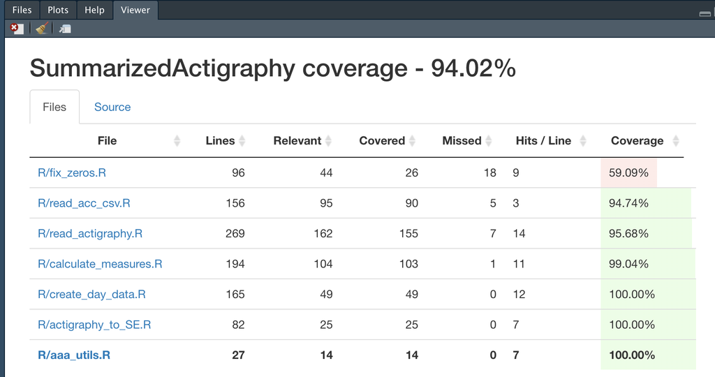

```r
covr::package_coverage() # run tests
covr::report() # get a report
covr::report(covr::package_coverage(type = "all")) # run them all
usethis::use_github_action("test-coverage") # test it on GitHub, put CODECOV_TOKEN in SECRET
```

## Process

- Go to Build → Load All to load all functions
- Change your code, write functions
- Build → Check Package
- Fix errors/notes
- Make tests
- Check code coverage
- Iterate

## That’s a lot of it - next slides are gravy

## Submitting to CRAN

```r
devtools::spell_check()
devtools::check_win_devel()
devtools::show_news()
usethis::use_cran_comments()
devtools::release() # do this if to be sure
devtools::submit_cran() # use only if you know what you're doing
```

## `pkgdown`

Want a site that has nice documentation: enter `pkgdown`!

```r
usethis::use_pkgdown()
usethis::use_github_action("pkgdown")
usethis::use_pkgdown_github_pages() #
```

README is your `index.html`

Vignettes are in `Articles`

## Checking Packages in the Past

**“But does it work on someone else’s machine or just mine?”**

[figure not shown]

https://memegenerator.net/instance/85107524/thinking-stick-man-ask-friend-to-check-my-package-why-arent-they-done-yet

## Continuous integration (Thoughtworks.com)

> Continuous Integration (CI) is a development practice that requires developers to integrate code into a shared repository several times a day. Each check-in is then verified by an automated build, allowing teams to detect problems early.

[figure not shown]

[figure not shown]

[figure not shown]

## Building CI and README

```r
usethis::use_git() # make a Git repo
usethis::use_github() # must have GITHUB_PAT set up
usethis::use_github(protocol = "https") # must have GITHUB_PAT set up
usethis::use_readme_rmd() # make a readme
usethis::use_github_action("check-standard")
```

## GitHub Actions - Build all 3 OSes

https://github.com/r-lib/actions

[figure not shown]

## GitHub Actions

```r
usethis::use_github_action("check-standard")
```

- adds file to `.github/workflows/`

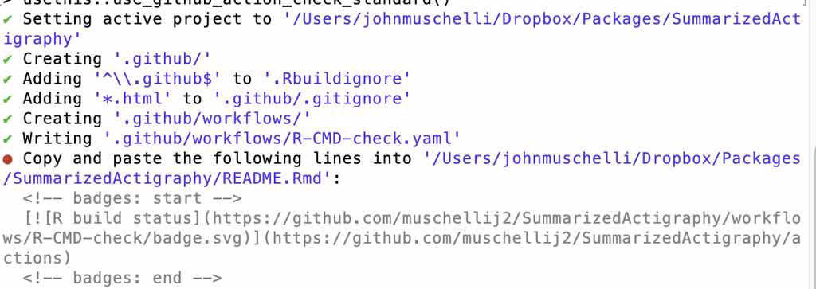

## Adding to the `README.Rmd`

These function adds following lines, changing `GITHUB_USERNAME/REPO` to the correct version

```
[![R build status](https://github.com/GITHUB_USERNAME/REPO/workflows/R-CMD-check/badge.svg)](https://github.com/GITHUB_USERNAME/REPO/actions)
```

or a general badge:

```r
usethis::use_badge("Travis-CI Build Status",
src = "https://travis-ci.com/GITHUB_USERNAME/REPO.svg?branch=master",
href = "https://travis-ci.com/GITHUB_USERNAME/REPO")
```

to the `README.Rmd`.

## S3, S4, Reference Classes

- S3 - simple - just say `class(x) = "myS3Class"`
  - Usually List of objects
  - http://adv-r.had.co.nz/S3.html
- S4 - more complex - see `new`
  - name, representation (slots), and inheritance (does it act like an array/list)
  - http://adv-r.had.co.nz/S4.html
- Reference Classes
  - very different, `class$method()`
  - http://adv-r.had.co.nz/R5.html

## S3, S4 Methods

- S3 :`bar <- function(y) UseMethod("bar", y)`
  - `bar.myS3Class` will allow you to use `bar(x)`
- S4 :`setGeneric("myGeneric", function(x) standardGeneric("myGeneric"))`

```r
setMethod("myGeneric", signature(x = "myS3Class"), function(x, y) {
 x@slot + y
})
```

## Compiled Code: C and C++

See http://r-pkgs.had.co.nz/src.html

- The `src/` folder has compiled code.
- `cleanup` generally deletes intermediate or downloaded files run in `configure`.
- `configure` runs code before `make` is run
- `Makevars` or a `Makefile` gives direction for compiling code
- There are `configure.win` and `Makevars.win` for Windows-specific setup.
- See`.Call` for calling these compiled functions.

Using `Rcpp` is a different framework.